# Notebook 01 — Python as a Computational Tool (MMAE 350)

**Goals**

1. Confirm your Python/Jupyter workflow works
2. Practice basic calculations and arrays with NumPy
3. Solve a small linear system
4. Make a simple plot
5. Practice “interpretation”: What does the output mean physically/mathematically?

## 1. The Computational Mechanics Workflow

In this course, we repeatedly follow this loop:

1. Physical model
2. Governing equations
3. Discretization
4. Numerical solution
5. Interpretation & validation

Today’s notebook focuses on the *tooling* needed to execute steps 3–5.

```python
# If this cell runs, your notebook execution is working.
print("Hello MMAE 350!")
```

```
Hello MMAE 350!
```

## 2. Quick Python Warm-Up (Scalars)

Python can be used as a scientific calculator. Run the cell, then modify it.

```python
L = 2.0      # meters
q0 = 1000.0  # N/m
total_load = q0 * L
total_load
```

```
2000.0
```

**Try this:** change `L` to `3.0` and `q0` to `1500.0`. What happens to `total_load`?  
Write one sentence here describing what changed.

## 3. NumPy Arrays

Most computational mechanics is vectorized: we work with arrays, not single numbers.

```python
import numpy as np

x = np.linspace(0.0, 1.0, 6)  # 6 points from 0 to 1
x
```

```
array([0. , 0.2, 0.4, 0.6, 0.8, 1. ])
```

```python
dx = x[1] - x[0]
dx
```

```
0.2
```

### Array slicing

Slicing is used constantly when building numerical methods.

```python
print("x[2:5] =", x[2:5])   # entries 2, 3, 4
print("x[::2] =", x[::2])   # every other entry
```

```
x[2:5] = [0.4 0.6 0.8]
x[::2] = [0.  0.4 0.8]
```

## 4. Linear Algebra: Solve a Small System

Many discretizations lead to linear systems of the form:

[ A\mathbf{x} = \mathbf{b}. ]

We will solve a small example and interpret the result.

```python
A = np.array([[3.0, 1.0],
              [1.0, 2.0]])
b = np.array([9.0, 8.0])

sol = np.linalg.solve(A, b)
sol
```

```
array([2., 3.])
```

**Interpretation prompt:**  
What does it mean to “solve” (A\mathbf{x}=\mathbf{b})?  
In one sentence, explain what the output represents.

## 5. Plotting (Matplotlib)

Plots are one of the main ways we interpret computational results.

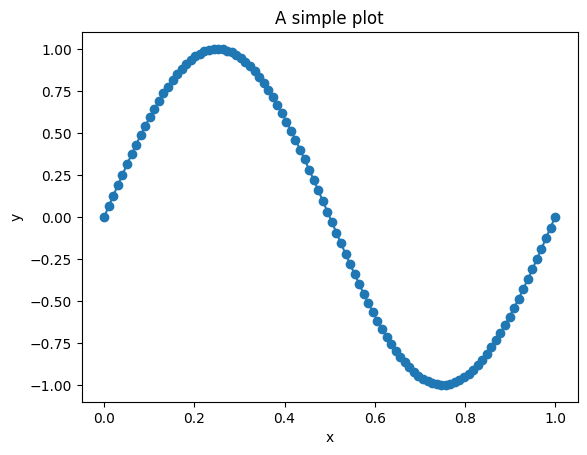

```python
import matplotlib.pyplot as plt

x = np.linspace(0.0, 1.0, 100)  # 100 points from 0 to 1
y = np.sin(2*np.pi*x)

plt.figure()
plt.plot(x, y, marker="o")
plt.xlabel("x")
plt.ylabel("y")
plt.title("A simple plot")
plt.show()
```

**Try this:** change the function definition to `y = x**2` and re-run the plot.  
What changed? Why?

## 6. Wrap-Up

In this notebook you:

- ran Python code inside Jupyter
- worked with arrays and slicing
- solved a small linear system
- created a simple plot

These are the core mechanics we’ll reuse throughout the semester.